```python
%%html
<link rel="stylesheet" type="text/css" href="rise.css" />
```

```python
import numpy as np
import pandas as pd
import matplotlib.pyplot as plt
%config InlineBackend.figure_format = 'retina'
plt.style.use('bmh')
plt.rcParams['lines.markeredgecolor'] = 'w'
plt.rcParams['lines.markeredgewidth'] = 0.5
plt.rcParams['figure.figsize'] = [8, 6]
```

# Support Vector Machine (SVM) classifier

**Learning goals**

- You will understand the concept and be ablr to use a support vector machine classifier.

A decision boundary used for binary classification.

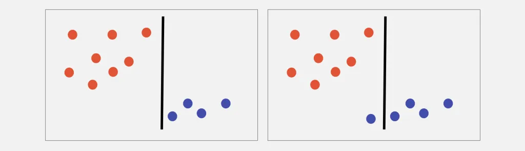

Optimal boundary maximizes the distance between each class (margin).

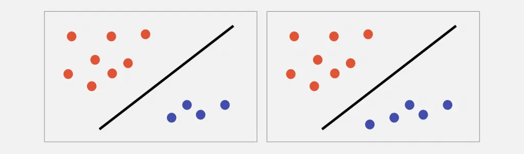

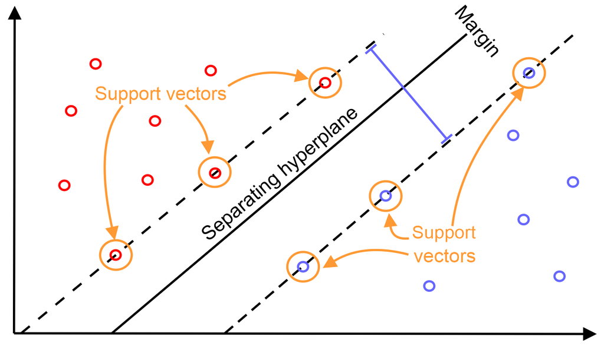

Multinomial one-vs-one classification with SVM.

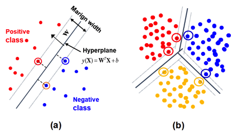

Expression levels of 77 proteins measured in the cerebral cortex of 8 classes of control and Down syndrome (Ts65Dn) mice exposed to context fear conditioning.

https://www.kaggle.com/ruslankl/mice-protein-expression

```python
import pandas as pd
df = pd.read_csv('data/Data_Cortex_Nuclear.csv')
df
```

|  | MouseID | DYRK1A_N | ITSN1_N | BDNF_N | NR1_N | NR2A_N | pAKT_N | pBRAF_N | pCAMKII_N | pCREB_N | ... | pCFOS_N | SYP_N | H3AcK18_N | EGR1_N | H3MeK4_N | CaNA_N | Genotype | Treatment | Behavior | class |
| --- | --- | --- | --- | --- | --- | --- | --- | --- | --- | --- | --- | --- | --- | --- | --- | --- | --- | --- | --- | --- | --- |
| 0 | 309_1 | 0.503644 | 0.747193 | 0.430175 | 2.816329 | 5.990152 | 0.218830 | 0.177565 | 2.373744 | 0.232224 | ... | 0.108336 | 0.427099 | 0.114783 | 0.131790 | 0.128186 | 1.675652 | Control | Memantine | C/S | c-CS-m |
| 1 | 309_2 | 0.514617 | 0.689064 | 0.411770 | 2.789514 | 5.685038 | 0.211636 | 0.172817 | 2.292150 | 0.226972 | ... | 0.104315 | 0.441581 | 0.111974 | 0.135103 | 0.131119 | 1.743610 | Control | Memantine | C/S | c-CS-m |
| 2 | 309_3 | 0.509183 | 0.730247 | 0.418309 | 2.687201 | 5.622059 | 0.209011 | 0.175722 | 2.283337 | 0.230247 | ... | 0.106219 | 0.435777 | 0.111883 | 0.133362 | 0.127431 | 1.926427 | Control | Memantine | C/S | c-CS-m |
| 3 | 309_4 | 0.442107 | 0.617076 | 0.358626 | 2.466947 | 4.979503 | 0.222886 | 0.176463 | 2.152301 | 0.207004 | ... | 0.111262 | 0.391691 | 0.130405 | 0.147444 | 0.146901 | 1.700563 | Control | Memantine | C/S | c-CS-m |
| 4 | 309_5 | 0.434940 | 0.617430 | 0.358802 | 2.365785 | 4.718679 | 0.213106 | 0.173627 | 2.134014 | 0.192158 | ... | 0.110694 | 0.434154 | 0.118481 | 0.140314 | 0.148380 | 1.839730 | Control | Memantine | C/S | c-CS-m |
| ... | ... | ... | ... | ... | ... | ... | ... | ... | ... | ... | ... | ... | ... | ... | ... | ... | ... | ... | ... | ... | ... |
| 1075 | J3295_11 | 0.254860 | 0.463591 | 0.254860 | 2.092082 | 2.600035 | 0.211736 | 0.171262 | 2.483740 | 0.207317 | ... | 0.183324 | 0.374088 | 0.318782 | 0.204660 | 0.328327 | 1.364823 | Ts65Dn | Saline | S/C | t-SC-s |
| 1076 | J3295_12 | 0.272198 | 0.474163 | 0.251638 | 2.161390 | 2.801492 | 0.251274 | 0.182496 | 2.512737 | 0.216339 | ... | 0.175674 | 0.375259 | 0.325639 | 0.200415 | 0.293435 | 1.364478 | Ts65Dn | Saline | S/C | t-SC-s |
| 1077 | J3295_13 | 0.228700 | 0.395179 | 0.234118 | 1.733184 | 2.220852 | 0.220665 | 0.161435 | 1.989723 | 0.185164 | ... | 0.158296 | 0.422121 | 0.321306 | 0.229193 | 0.355213 | 1.430825 | Ts65Dn | Saline | S/C | t-SC-s |
| 1078 | J3295_14 | 0.221242 | 0.412894 | 0.243974 | 1.876347 | 2.384088 | 0.208897 | 0.173623 | 2.086028 | 0.192044 | ... | 0.196296 | 0.397676 | 0.335936 | 0.251317 | 0.365353 | 1.404031 | Ts65Dn | Saline | S/C | t-SC-s |
| 1079 | J3295_15 | 0.302626 | 0.461059 | 0.256564 | 2.092790 | 2.594348 | 0.251001 | 0.191811 | 2.361816 | 0.223632 | ... | 0.187556 | 0.420347 | 0.335062 | 0.252995 | 0.365278 | 1.370999 | Ts65Dn | Saline | S/C | t-SC-s |

1080 rows × 82 columns

Goal is to use protein expression levels to classify mice. Each mouse in the dataset belongs to one of the following eight classes:

1. c-CS-s: control mice, stimulated to learn, injected with saline
2. c-CS-m: control mice, stimulated to learn, injected with memantine
3. c-SC-s: control mice, not stimulated to learn, injected with saline
4. c-SC-m: control mice, not stimulated to learn, injected with memantine
5. t-CS-s: trisomy mice, stimulated to learn, injected with saline
6. t-CS-m: trisomy mice, stimulated to learn, injected with memantine
7. t-SC-s: trisomy mice, not stimulated to learn, injected with saline
8. t-SC-m: trisomy mice, not stimulated to learn, injected with memantine

which are combinations of:

- Control vs. down syndrome.
- Did or did not recieve behavioral conditioning.
- Saline vs. memantine injection.

First, throw out features and data points with missing measurements.

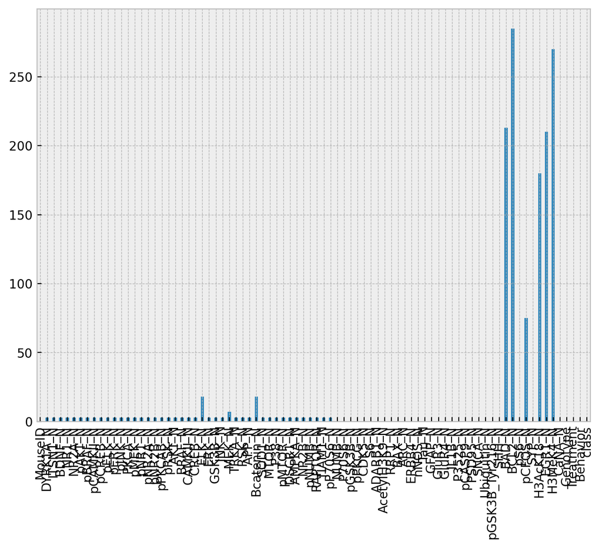

```python
df.isnull().sum().plot.bar();
```

```python
miss_too_many = df.isnull().sum() > 10

miss_too_many
```

```
MouseID      False
DYRK1A_N     False
ITSN1_N      False
BDNF_N       False
NR1_N        False
             ...
CaNA_N       False
Genotype     False
Treatment    False
Behavior     False
class        False
Length: 82, dtype: bool
```

```python
df2 = df.loc[:, ~miss_too_many]

df.shape, df2.shape
```

```
((1080, 82), (1080, 74))
```

```python
# discard mice with missing measurements
df2 = df2.dropna()

df2.shape
```

```
(1073, 74)
```

The dataset we will use for building a classsification model.

```python
df2
```

|  | MouseID | DYRK1A_N | ITSN1_N | BDNF_N | NR1_N | NR2A_N | pAKT_N | pBRAF_N | pCAMKII_N | pCREB_N | ... | Ubiquitin_N | pGSK3B_Tyr216_N | SHH_N | pS6_N | SYP_N | CaNA_N | Genotype | Treatment | Behavior | class |
| --- | --- | --- | --- | --- | --- | --- | --- | --- | --- | --- | --- | --- | --- | --- | --- | --- | --- | --- | --- | --- | --- |
| 0 | 309_1 | 0.503644 | 0.747193 | 0.430175 | 2.816329 | 5.990152 | 0.218830 | 0.177565 | 2.373744 | 0.232224 | ... | 1.044979 | 0.831557 | 0.188852 | 0.106305 | 0.427099 | 1.675652 | Control | Memantine | C/S | c-CS-m |
| 1 | 309_2 | 0.514617 | 0.689064 | 0.411770 | 2.789514 | 5.685038 | 0.211636 | 0.172817 | 2.292150 | 0.226972 | ... | 1.009883 | 0.849270 | 0.200404 | 0.106592 | 0.441581 | 1.743610 | Control | Memantine | C/S | c-CS-m |
| 2 | 309_3 | 0.509183 | 0.730247 | 0.418309 | 2.687201 | 5.622059 | 0.209011 | 0.175722 | 2.283337 | 0.230247 | ... | 0.996848 | 0.846709 | 0.193685 | 0.108303 | 0.435777 | 1.926427 | Control | Memantine | C/S | c-CS-m |
| 3 | 309_4 | 0.442107 | 0.617076 | 0.358626 | 2.466947 | 4.979503 | 0.222886 | 0.176463 | 2.152301 | 0.207004 | ... | 0.990225 | 0.833277 | 0.192112 | 0.103184 | 0.391691 | 1.700563 | Control | Memantine | C/S | c-CS-m |
| 4 | 309_5 | 0.434940 | 0.617430 | 0.358802 | 2.365785 | 4.718679 | 0.213106 | 0.173627 | 2.134014 | 0.192158 | ... | 0.997775 | 0.878668 | 0.205604 | 0.104784 | 0.434154 | 1.839730 | Control | Memantine | C/S | c-CS-m |
| ... | ... | ... | ... | ... | ... | ... | ... | ... | ... | ... | ... | ... | ... | ... | ... | ... | ... | ... | ... | ... | ... |
| 1075 | J3295_11 | 0.254860 | 0.463591 | 0.254860 | 2.092082 | 2.600035 | 0.211736 | 0.171262 | 2.483740 | 0.207317 | ... | 1.261651 | 0.962942 | 0.275547 | 0.115806 | 0.374088 | 1.364823 | Ts65Dn | Saline | S/C | t-SC-s |
| 1076 | J3295_12 | 0.272198 | 0.474163 | 0.251638 | 2.161390 | 2.801492 | 0.251274 | 0.182496 | 2.512737 | 0.216339 | ... | 1.254872 | 0.983690 | 0.283207 | 0.113614 | 0.375259 | 1.364478 | Ts65Dn | Saline | S/C | t-SC-s |
| 1077 | J3295_13 | 0.228700 | 0.395179 | 0.234118 | 1.733184 | 2.220852 | 0.220665 | 0.161435 | 1.989723 | 0.185164 | ... | 1.242248 | 0.976609 | 0.290843 | 0.118948 | 0.422121 | 1.430825 | Ts65Dn | Saline | S/C | t-SC-s |
| 1078 | J3295_14 | 0.221242 | 0.412894 | 0.243974 | 1.876347 | 2.384088 | 0.208897 | 0.173623 | 2.086028 | 0.192044 | ... | 1.301071 | 0.989286 | 0.306701 | 0.125295 | 0.397676 | 1.404031 | Ts65Dn | Saline | S/C | t-SC-s |
| 1079 | J3295_15 | 0.302626 | 0.461059 | 0.256564 | 2.092790 | 2.594348 | 0.251001 | 0.191811 | 2.361816 | 0.223632 | ... | 1.267120 | 1.020383 | 0.292330 | 0.118899 | 0.420347 | 1.370999 | Ts65Dn | Saline | S/C | t-SC-s |

1073 rows × 74 columns

Use an SVM classifier to predict mouse class based on protein expression in cortex.

```python
from sklearn.utils import shuffle

X = df2.loc[:,'DYRK1A_N':'CaNA_N']  # just protein expression levels
y = df2['class']

# shuffle data
X, y = shuffle(X, y, random_state=0)

X.shape, y.shape, y.unique()
```

```
((1073, 69),
 (1073,),
 array(['t-CS-s', 'c-SC-m', 'c-SC-s', 't-CS-m', 'c-CS-s', 't-SC-s',
        't-SC-m', 'c-CS-m'], dtype=object))
```

```python
from sklearn.svm import SVC

model = SVC(kernel='linear')
```

Get cross validated accuracy.

```python
from sklearn.model_selection import cross_val_score

cv_accuracy = cross_val_score(model, X, y, cv=10, scoring='accuracy')
cv_accuracy
```

```
array([0.9537037 , 0.94444444, 0.91666667, 0.96261682, 0.96261682,
       0.93457944, 0.97196262, 0.94392523, 0.94392523, 0.92523364])
```

Mean accuracy across folds is likely a reasonable measure of the model's accuracy.

```python
accuracy = np.mean(cv_accuracy)
accuracy
```

```
0.9459674627898927
```

Get cross validated predictions.

```python
from sklearn.model_selection import cross_val_predict

y_pred = cross_val_predict(model, X, y, cv=10)

y.shape, y_pred.shape
```

```
((1073,), (1073,))
```

Plot a confusion matrix.

*Note that results are already a bit better than the logistic regression model from the last lecture.*

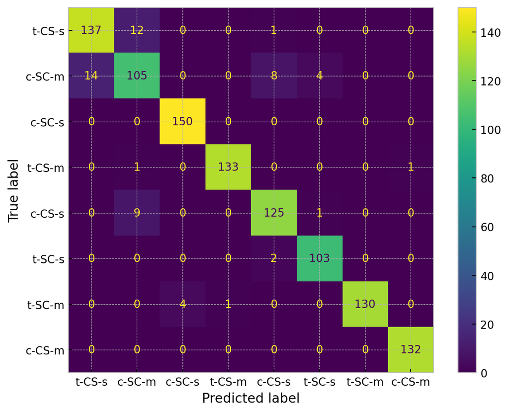

```python
from sklearn.metrics import confusion_matrix, ConfusionMatrixDisplay

cm = confusion_matrix(y, y_pred)
ConfusionMatrixDisplay(confusion_matrix=cm, display_labels=y.unique()).plot();
```

**Soft margin** allows for misclassifications in the training set. The penalty for missclassifications is scaled by a hyperparameter `C` which sets a compromise between missclassifications and maximizing the margin.

- **left**: Larger penalty for missclassifications.
- **right**: Smaller penalty for missclassifications.

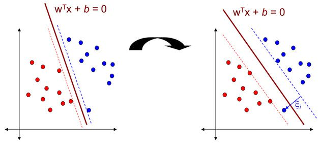

### Exercise

Determine the optimal value of the penalty `C` for predicting a mouse's class based on its cortical protein expression profile.

```python
# from sklearn.model_selection import GridSearchCV

# # SVM linear classifier
# model = ...

# # try these values for the penalty C
# params = {'C': np.logspace(-1, 2, 30)}

# # setup grid search cross validation to find best C
# search = ...

# # do the search
# ...

# best_C = search.best_params_['C']
# best_model = search.best_estimator_
# best_model
```

### Exercise key

Determine the optimal value of the penalty `C` for predicting a mouse's class based on its cortical protein expression profile.

```python
from sklearn.model_selection import GridSearchCV

# SVM linear classifier
model = SVC(kernel='linear')

# try these values for the penalty C
params = {'C': np.logspace(-1, 2, 30)}

# setup grid search cross validation to find best C
search = GridSearchCV(model, params, cv=10, scoring='accuracy')

# do the search
search.fit(X, y)

best_C = search.best_params_['C']
best_model = search.best_estimator_
best_model
```

```
SVC(C=23.95026619987486, kernel='linear')
```

Plot a confusion matrix for the SVM model with optimal soft margin penalty.

*This is an improvement over the default penalty.*

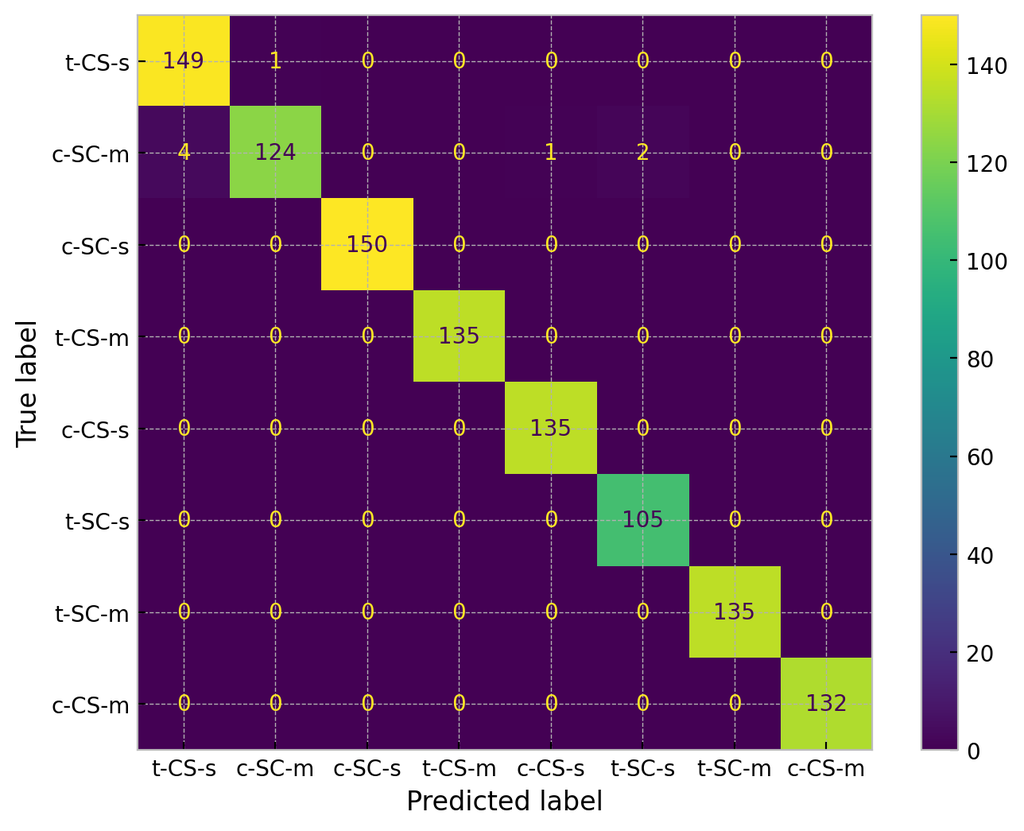

```python
y_pred = cross_val_predict(best_model, X, y, cv=10)
cm = confusion_matrix(y, y_pred)
ConfusionMatrixDisplay(confusion_matrix=cm, display_labels=y.unique()).plot();
```

Model with optimal penalty.

```python
cv_accuracy = cross_val_score(best_model, X, y, cv=10, scoring='accuracy')
accuracy = np.mean(cv_accuracy)
accuracy
```

```
0.9925233644859814
```

Model with very small penalty.

```python
small_penalty_model = SVC(kernel='linear', C=1e-9)
cv_accuracy = cross_val_score(small_penalty_model, X, y, cv=10, scoring='accuracy')
accuracy = np.mean(cv_accuracy)
accuracy
```

```
0.23948598130841123
```

SVM can incorporate nonlinear decision boundaries. In `sklearn.svm.SVC` this is set via the `kernel` parameter.

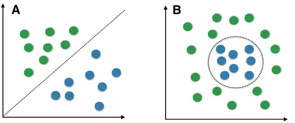

SVM polynomial kernel.

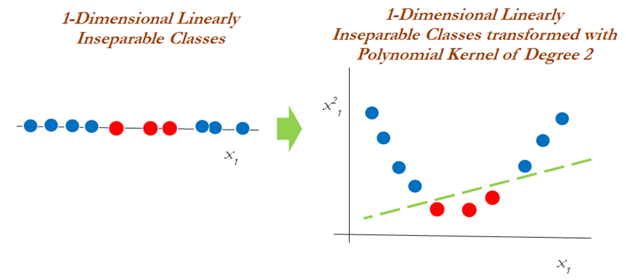

SVM nonlinar boundary.

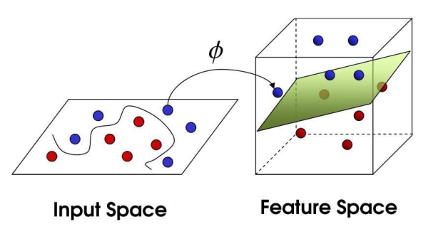

Contour boundaries.

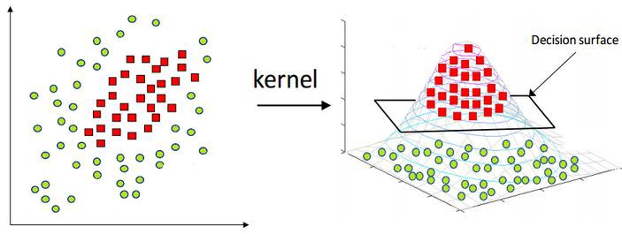

A decent video explaining the basics of SVM classfiers.

https://www.youtube.com/watch?v=efR1C6CvhmE&t=0s

Some made-up data to illustrate a nonlinear boundary in two dimensions.

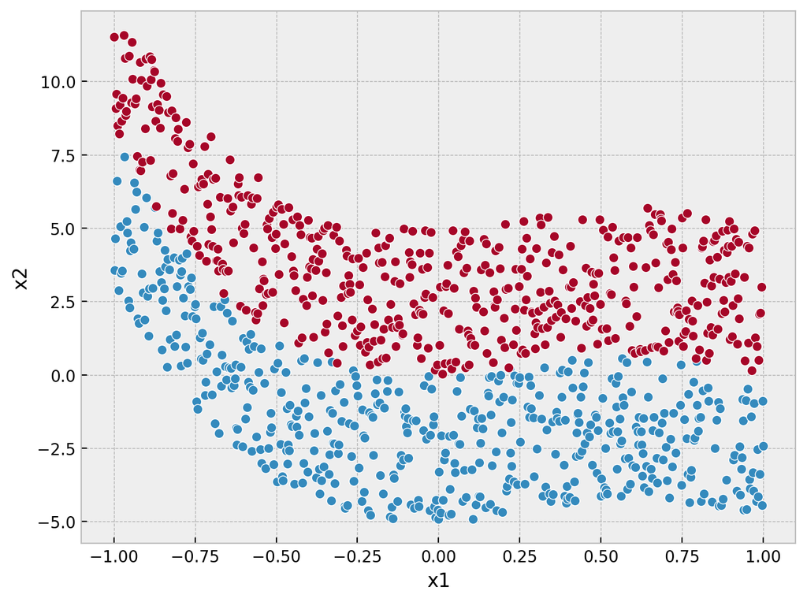

```python
np.random.seed(80)
x1 = np.linspace(-1, 1, 1000)
a, b, c = np.random.uniform(-10, 10, 3)
m = a * x1 + b * x1**2 + c * x1**3
x2 = m + np.random.uniform(0, 5, x1.shape) * np.random.choice([-1, 1], x1.shape)
y = np.zeros(len(x1))
y[x2 > m] = 1

plt.plot(x1[y == 0], x2[y == 0], 'o')
plt.plot(x1[y == 1], x2[y == 1], 'o')
plt.xlabel('x1')
plt.ylabel('x2');
```

```python
X = np.vstack([x1, x2]).T

X.shape, y.shape
```

```
((1000, 2), (1000,))
```

Radial Basis Function (RBF) kernel ~ Gaussian kernel

```python
from sklearn.model_selection import GridSearchCV

model = SVC(kernel='rbf')
params = {'C': np.logspace(-1, 3, 40)}

search = GridSearchCV(model, params, cv=10, scoring='accuracy')
search.fit(X, y)

best_model = search.best_estimator_
best_model
```

```
SVC(C=388.81551803080856)
```

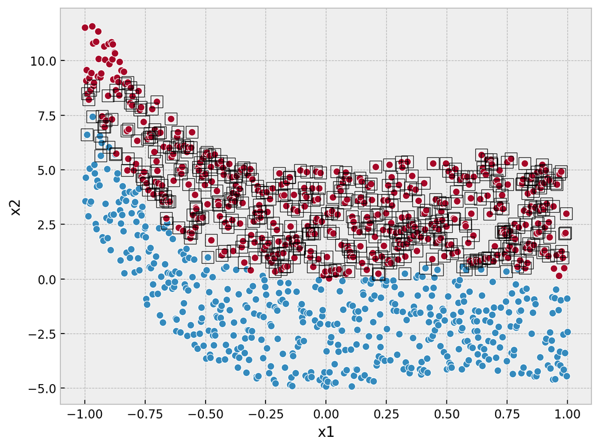

```python
y_pred = cross_val_predict(best_model, X, y, cv=10)

plt.plot(x1[y == 0], x2[y == 0], 'o')
plt.plot(x1[y == 1], x2[y == 1], 'o')
plt.plot(x1[y_pred == 1], x2[y_pred == 1], 's', ms=10, mfc='none', mec='k')
plt.xlabel('x1')
plt.ylabel('x2');
```

### Exercise

Use an SVM classifier with a radial basis function kernel to predict a mouse's class based on its cortical protein expression profile.

```python
X = df2.loc[:,'DYRK1A_N':'CaNA_N']  # just protein expression levels
y = df2['class']

X, y = shuffle(X, y, random_state=0)

X.shape, y.shape, y.unique()
```

```
((1073, 69),
 (1073,),
 array(['t-CS-s', 'c-SC-m', 'c-SC-s', 't-CS-m', 'c-CS-s', 't-SC-s',
        't-SC-m', 'c-CS-m'], dtype=object))
```

```python
# model = ...
# params = {'C': np.logspace(-1, 3, 40)}

# search = ...
# ...

# best_model = search.best_estimator_
# best_model
```

### Exercise key

Use an SVM classifier with a radial basis function kernel to predict a mouse's class based on its cortical protein expression profile.

```python
X = df2.loc[:,'DYRK1A_N':'CaNA_N']  # just protein expression levels
y = df2['class']

X, y = shuffle(X, y, random_state=0)

X.shape, y.shape, y.unique()
```

```
((1073, 69),
 (1073,),
 array(['t-CS-s', 'c-SC-m', 'c-SC-s', 't-CS-m', 'c-CS-s', 't-SC-s',
        't-SC-m', 'c-CS-m'], dtype=object))
```

```python
model = SVC(kernel='rbf')
params = {'C': np.logspace(-1, 3, 40)}

search = GridSearchCV(model, params, cv=10, scoring='accuracy')
search.fit(X, y)

best_model = search.best_estimator_
best_model
```

```
SVC(C=94.26684551178855)
```

Let's use a confusion matrix to visualize how well the SVM model with radial basis function did.

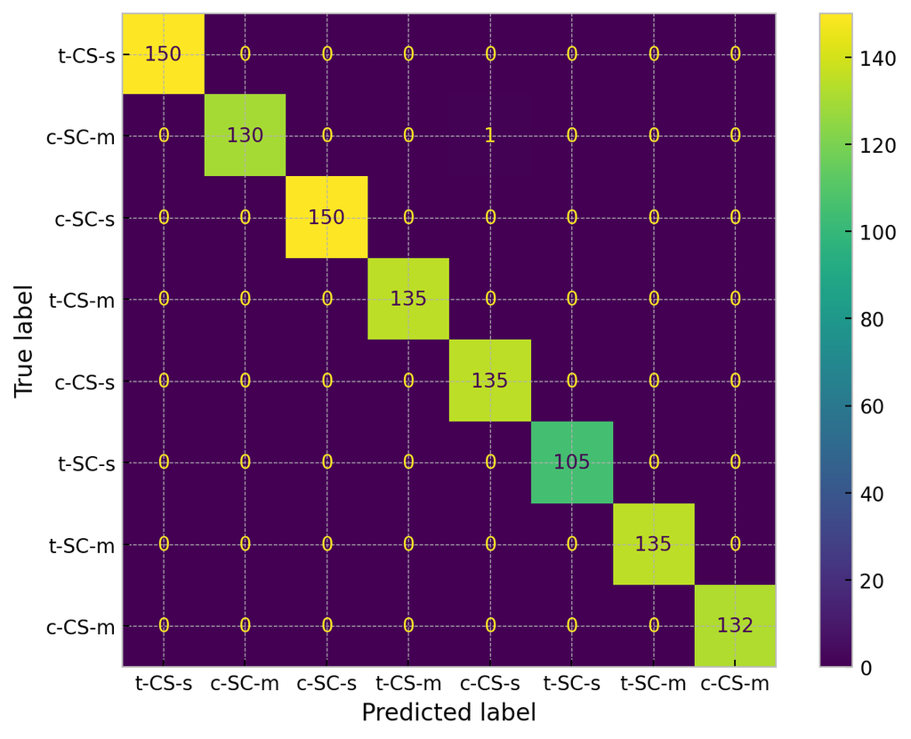

```python
y_pred = cross_val_predict(best_model, X, y, cv=10)
cm = confusion_matrix(y, y_pred)
ConfusionMatrixDisplay(confusion_matrix=cm, display_labels=y.unique()).plot();
```

And the model's cross validated accuracy...

```python
cv_accuracy = cross_val_score(best_model, X, y, cv=10, scoring='accuracy')
accuracy = np.mean(cv_accuracy)
accuracy
```

```
0.9990654205607477
```

Just a reminder, that at the end of the day once you have selected a model, you should fit it to all of your data.

```python
best_model.fit(X, y);
```

Now you whould distribute this model to others or apply it to make predictions about new data.